# headline_michau

```python
import pandas as pd
import tensorflow as tf
from transformers import AutoTokenizer
import re
from transformers import AdamWeightDecay
from datasets import Dataset
import math
import numpy as np
from transformers import DataCollatorForSeq2Seq
from transformers import TFAutoModelForSeq2SeqLM
import torch
import evaluate
```

[output not shown]

```python
tf.config.experimental.list_physical_devices(device_type='GPU')
```

```
[PhysicalDevice(name='/physical_device:GPU:0', device_type='GPU'),
 PhysicalDevice(name='/physical_device:GPU:1', device_type='GPU')]
```

```python
def json_to_dataset(filename):
    f = open(filename)
    df = pd.read_json(f)
    f.close()
    df['news'] = df['news'].apply(lambda x: re.sub(r'\([^)]*\)', '', x))
    #df = df.iloc[:10000]
    print(df.columns)
    print(df.head)
    dataset = Dataset.from_pandas(df)
    dataset = dataset.train_test_split(test_size=0.2)
    return dataset
```

```python
train_data = json_to_dataset('Train_Headline_Generation.json')
```

```
Index(['news', 'headline'], dtype='object')
<bound method NDFrame.head of                                                     news  \
0       As of Jan. 1, Walmart will no longer offer 30...
1       Dax Shepard and Kristen Bell got married at t...
2       Nancy Reagan, the helpmate, backstage adviser...
3       American Airlines faces FAA fines of more tha...
4       Ingrid Lyne, the Seattle mom allegedly murder...
...                                                  ...
21152   For hundreds of years, an imposing white oak ...
21153   Age may be nothing but a number, but one octo...
21154   For the first time, women in their early 30s ...
21155   Three more bodies were found in the ruins of ...
21156   Authorities now say 17 people have died in So...

                                                headline
0       30K Walmart Part-Timers to Lose Health Insurance
1         Dax Shepard: Wedding to Kristen Bell Cost $142
2                                Nancy Reagan Dead at 94
3      American Airlines Faces $7M Fine for Safety Vi...
4       $222K Raised for Kids of Mom Dismembered on Date
...                                                  ...
21152       NJ Town's Iconic 600-Year-Old Tree Will Fall
21153         Tokyo's Hottest DJ Is an 82-Year-Old Woman
21154      Report Reveals Historic 1st for American Moms
21155  3 More Bodies Found in Tenn. Wildfire Ruins, T...
21156    Death Toll From California Mudslide Rises to 17

[21157 rows x 2 columns]>
```

### The model is based on t5-base and has been trained on a collection of 500k articles with headings. Its purpose is to create a one-line heading suitable for the given article. https://huggingface.co/Michau/t5-base-en-generate-headline

```python
model_name = "Michau/t5-base-en-generate-headline"
```

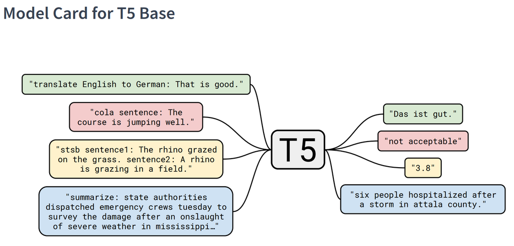

T5 is Text-to-Text-Transfer-Transformer model. It takes in text input from left for various NLP tasks and outputs the text for that respective task.

T5 is slightly different from Masked Language Model such as BERT. Masked Language Models are Bidirectional models which use Mask token for each word while T5 replaces multiple consecutive tokens with a single Mask keyword. Since the final objective is to have trained a model that inputs text and outputs text, the targets were designed to produce a sequence, unlike BERT, that tries to output one word (itself). So it is suitable for text summarization and headline generation.

```python
'''
model_names = ["it5/it5-base-headline-generation",
               "it5/it5-small-headline-generation",
               "it5/mt5-base-headline-generation",
               "it5/mt5-small-headline-generation",
               "it5/it5-efficient-small-el32-headline-generation",
               "Michau/t5-base-en-generate-headline"]
'''
```

To prefix the input with a prompt so T5 knows this is a headline generation task

```python
prefix = "headline: "
max_len = 3024
max_l = 1028
```

```python
def preprocess_function(examples):
    inputs = [prefix + doc for doc in examples["news"]]
    model_inputs = tokenizer(inputs, max_length=max_len, truncation=True)
    labels = tokenizer(text_target=examples["headline"], max_length=max_l, truncation=True)
    model_inputs["labels"] = labels["input_ids"]
    return model_inputs
```

To apply the preprocess function over the entire dataset

```python
tokenizer = AutoTokenizer.from_pretrained(model_name)
tokenized = train_data.map(preprocess_function, batched=True, num_proc=4,
                        remove_columns=train_data['train'].column_names)
```

[output not shown]

```python
#tokenized = train_data.map(preprocess_function, batched=True)
```

To create batches using DataCollatorForSeq2Seq, which dynamically pads the sentences to the longest length in a batch during collation. This is more efficient than padding the whole dataset to the maximum length.

```python
data_collator = DataCollatorForSeq2Seq(tokenizer=tokenizer,
                                           model=model_name,
                                           return_tensors="tf")
optimizer = AdamWeightDecay(learning_rate=3e-4, weight_decay_rate=0.01)
```

To load pretrained T5-base with AutoModelForSeq2SeqLM

```python
model = TFAutoModelForSeq2SeqLM.from_pretrained(model_name)
```

[output not shown]

To convert datasets to the tf.data.Dataset format

```python
tf_train_set = model.prepare_tf_dataset(
    tokenized["train"],
    shuffle=True,
    batch_size=16,
    collate_fn=data_collator,
)

tf_test_set = model.prepare_tf_dataset(
    tokenized["test"],
    shuffle=False,
    batch_size=16,
    collate_fn=data_collator,
)
```

```
You're using a T5TokenizerFast tokenizer. Please note that with a fast tokenizer, using the `__call__` method is faster than using a method to encode the text followed by a call to the `pad` method to get a padded encoding.
```

```python
model.compile(optimizer=optimizer)
```

```python
eval_loss = model.evaluate(tf_test_set)
print(f"Pretrained LM Perplexity: {math.exp(eval_loss):.2f}")
```

```
Pretrained LM Perplexity: 12.43
```

```python
#model.fit(x=tf_train_set, validation_data=tf_test_set, batch_size=6, epochs=5)
model.fit(x=tf_train_set, validation_data=tf_test_set, batch_size=6, epochs=1)
#eval_loss = model.evaluate(tf_test_set)
t#print(f"Finetuned Perplexity: {math.exp(eval_loss):.2f}")
```

[output not shown]

```python
import matplotlib.pyplot as plt
plt.plot(history.history['loss'])
plt.plot(history.history['val_loss'])
plt.title('model loss')
plt.ylabel('loss')
plt.xlabel('epoch')
plt.legend(['train', 'test'], loc='upper left')
plt.show()
```

[output not shown]

```python
f = open('Dev_Headline_Generation.json')
df = pd.read_json(f)
df['news'] = df['news'].apply(lambda x: re.sub(r'\([^)]*\)', '', x))
#df = df.iloc[45:50]
#df = df.iloc[100:500]
f.close()
test_data = Dataset.from_pandas(df)
```

```python
def t5_predictions(data, tokenizer, model):
    text = prefix + data['news']
    inputs = tokenizer.encode_plus(text, return_tensors="pt").input_ids
    #input_ids = inputs['input_ids'].to(device)
    #attention_masks = inputs['attention_mask']

    outputs = model.generate(inputs,
                              max_length = 64, num_beams = 5, early_stopping = True)
    predictions = tokenizer.decode(outputs[0])
    result = re.sub("\<.*?\>","", predictions)
    return result
```

To load the ROUGE metric to calculates the similarity between the predicted headlines and actual headlines

```python
rouge = evaluate.load("rouge")
```

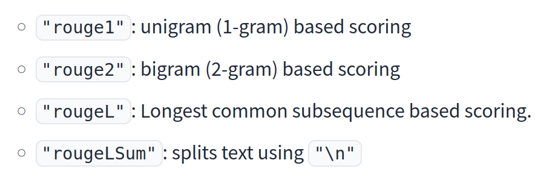

```python
tr = 0
for i in test_data:
    prediction = t5_predictions(i, tokenizer, model)
    answer = i['headline']
    print("Answer: ", answer)
    print("Prediction: ", prediction)
    print(rouge.compute(predictions=[prediction], references=[answer]))
    print("")
```

[output not shown]

```
Answer:  3rd Victim Dead in Quarry Shooting; Manhunt Still On
Prediction:   3 Dead, 5 Hurt in California Shooting Spree
{'rouge1': 0.35294117647058826, 'rouge2': 0.0, 'rougeL': 0.35294117647058826, 'rougeLsum': 0.35294117647058826}

Answer:  Stocks Up 305 in Election Rally
Prediction:   Dow Rises 305 on Election Day
{'rouge1': 0.3333333333333333, 'rouge2': 0.0, 'rougeL': 0.3333333333333333, 'rougeLsum': 0.3333333333333333}

Answer:  You Can Watch The Interview at 1pm
Prediction:   The Interview Is Available for $14.99
{'rouge1': 0.2857142857142857, 'rouge2': 0.16666666666666666, 'rougeL': 0.2857142857142857, 'rougeLsum': 0.2857142857142857}

Answer:  Murder Suspect, 10, Will Stay in Adult Jail
Prediction:   10-Year-Old Who Confessioned to Killing Woman Is Still in Prison
{'rouge1': 0.2, 'rouge2': 0.0, 'rougeL': 0.2, 'rougeLsum': 0.2}

Answer:  Tobacco Firms Knew of Radiation in Cigs—in 1959
Prediction:   Tobacco Companies Discovered Radiation in 1959
{'rouge1': 0.5333333333333333, 'rouge2': 0.3076923076923077, 'rougeL': 0.5333333333333333, 'rougeLsum': 0.5333333333333333}

Answer:  AIG Bonuses Higher Than Thought: $218M
Prediction:   AIG: Firm Paid Out $218M in Bonuses
{'rouge1': 0.4615384615384615, 'rouge2': 0.0, 'rougeL': 0.30769230769230765, 'rougeLsum': 0.30769230769230765}

Answer:  9 Months May Not Be 'Normal' Pregnancy, After All
Prediction:   Study: Pregnancy Can Vary by as Much as 5 Weeks
{'rouge1': 0.10526315789473685, 'rouge2': 0.0, 'rougeL': 0.10526315789473685, 'rougeLsum': 0.10526315789473685}

Answer:  Yahoo Lays Off 2K Workers
Prediction:   Yahoo Cuts 2,000 Jobs, 14% of Workforce
{'rouge1': 0.15384615384615385, 'rouge2': 0.0, 'rougeL': 0.15384615384615385, 'rougeLsum': 0.15384615384615385}

Answer:  Auto Bosses to Press Pelosi for Another $25B
Prediction:   Detroit's Big 3 CEOs to Meet With Pelosi for $25B
{'rouge1': 0.4210526315789474, 'rouge2': 0.11764705882352941, 'rougeL': 0.4210526315789474, 'rougeLsum': 0.4210526315789474}

Answer:  From Britain With Love: MI6 Seeks Minorities
Prediction:   MI6 Wants More Women, Minority Agents
{'rouge1': 0.15384615384615383, 'rouge2': 0.0, 'rougeL': 0.15384615384615383, 'rougeLsum': 0.15384615384615383}

```

[output cut: 9404 more lines]

```
Answer:  Federer Ekes Out 18th Grand Slam
Prediction:   Federer Wins 18th Major Title
{'rouge1': 0.3636363636363636, 'rouge2': 0.0, 'rougeL': 0.3636363636363636, 'rougeLsum': 0.3636363636363636}

Answer:  Laurence Fishburne Files for Divorce After 15-Year Marriage
Prediction:   Laurence Fishburne Files for Divorce From Wife of 15 Years
{'rouge1': 0.631578947368421, 'rouge2': 0.47058823529411764, 'rougeL': 0.631578947368421, 'rougeLsum': 0.631578947368421}

Answer:  3 Months After Baby, Janet Jackson, Hubby Split
Prediction:   Sources: Janet Jackson, Wissam Al Mana Split Up After 3 Months
{'rouge1': 0.631578947368421, 'rouge2': 0.23529411764705882, 'rougeL': 0.3157894736842105, 'rougeLsum': 0.3157894736842105}

Answer:  Jihadist Attack Kills 3 UN Peacekeepers
Prediction:   3 Peacekeepers Killed in Operation With Malian Defense Forces
{'rouge1': 0.26666666666666666, 'rouge2': 0.0, 'rougeL': 0.26666666666666666, 'rougeLsum': 0.26666666666666666}
```

### References:

[1] Prakhar Mishra. 2020. Understanding T5 Model : Text to Text Transfer Transformer Model. Towards Data Science https://towardsdatascience.com/understanding-t5-model-text-to-text-transfer-transformer-model-69ce4c165023.

[2] Summarization. Huggingface. https://huggingface.co/docs/transformers/tasks/summarization

```python
len(test_data)
```

```
2365
```

```python
tr = 0
for i in test_data:
    prediction = t5_predictions(i, tokenizer, model)
    answer = i['headline']
    print("Answer: ", answer)
    print("Prediction: ", prediction)
    print(rouge.compute(predictions=[prediction], references=[answer]))
    print("")
```

[output not shown]

```python
tr = 0
for i in test_data:
    prediction = t5_predictions(i, tokenizer, model)
    answer = i['headline']
    print("Answer: ", answer)
    print("Prediction: ", prediction)
    print(rouge.compute(predictions=[prediction], references=[answer]))
    print("")
```

[output not shown]

```
Answer:  2 Arrested for Allegedly Helping Denmark Shooter
Prediction:   Denmark Arrests 2 for Helping Killing Suspect
{'rouge1': 0.5714285714285714, 'rouge2': 0.0, 'rougeL': 0.42857142857142855, 'rougeLsum': 0.42857142857142855}

Answer:  Here's the Mix Tape Kurt Cobain Made at 21
Prediction:   'Disturbing' Kurt Cobain Mix Tape Released in 1988
{'rouge1': 0.4444444444444445, 'rouge2': 0.25, 'rougeL': 0.22222222222222224, 'rougeLsum': 0.22222222222222224}

Answer:  Canada Pledges $3.3B Aid for Automakers
Prediction:   Canada Gives GM, Chrysler $3.3B Bailout
{'rouge1': 0.42857142857142855, 'rouge2': 0.16666666666666666, 'rougeL': 0.42857142857142855, 'rougeLsum': 0.42857142857142855}

Answer:  How We 'Know' the World Will End on May 21
Prediction:   Camping: Noah Stole His Ark in 4990 BC
{'rouge1': 0.0, 'rouge2': 0.0, 'rougeL': 0.0, 'rougeLsum': 0.0}

Answer:  3 Dead in Mall Shooting
Prediction:   3 Dead in Baltimore Mall Shooting
{'rouge1': 0.9090909090909091, 'rouge2': 0.6666666666666665, 'rougeL': 0.9090909090909091, 'rougeLsum': 0.9090909090909091}

Answer:  2K Homes in Danger as Calif. Wildfires Spread
Prediction:   2K Homes in California Wildfires
{'rouge1': 0.6153846153846154, 'rouge2': 0.36363636363636365, 'rougeL': 0.6153846153846154, 'rougeLsum': 0.6153846153846154}

Answer:  Suspected Nazi Who Fled US Dead at 92
Prediction:   Auschwitz Suspect Dead at 92
{'rouge1': 0.4615384615384615, 'rouge2': 0.36363636363636365, 'rougeL': 0.4615384615384615, 'rougeLsum': 0.4615384615384615}

Answer:  Led Zeppelin Drops 2 Unheard Tracks
Prediction:   Led Zeppelin Releases 2 More Tracks
{'rouge1': 0.6666666666666666, 'rouge2': 0.20000000000000004, 'rougeL': 0.6666666666666666, 'rougeLsum': 0.6666666666666666}

Answer:  18 Arrested in Seattle Protests
Prediction:   18 Arrested in May Day Protests
{'rouge1': 0.7272727272727272, 'rouge2': 0.4444444444444445, 'rougeL': 0.7272727272727272, 'rougeLsum': 0.7272727272727272}

Answer:  Son, 9, Made Bad Mistake in Shooting: Dad
Prediction:   9-Year-Old Suspects at School Hearing on Gun Case
{'rouge1': 0.11111111111111112, 'rouge2': 0.0, 'rougeL': 0.11111111111111112, 'rougeLsum': 0.11111111111111112}

```

[output cut: 1544 more lines]

```
Answer:  $1.7M Ride Seeks Loving Owners
Prediction:   Bugatti Bets On 300 People Wanting $1.7M Car
{'rouge1': 0.26666666666666666, 'rouge2': 0.15384615384615385, 'rougeL': 0.26666666666666666, 'rougeLsum': 0.26666666666666666}

Answer:  Baseball's 'Rising Meteor' Dead in Crash at 22
Prediction:   St. Louis Cardinals' Oscar Tavern Dead in Car Crash
{'rouge1': 0.3333333333333333, 'rouge2': 0.125, 'rougeL': 0.3333333333333333, 'rougeLsum': 0.3333333333333333}

Answer:  Notification Center for Windows 8 May Be in Works
Prediction:   Microsoft's Windows Phone 8 Doesn't Have a Notification Center
{'rouge1': 0.39999999999999997, 'rouge2': 0.11111111111111112, 'rougeL': 0.19999999999999998, 'rougeLsum': 0.19999999999999998}

Answer:  Japan's SoftBank Snapping Up 70% of Sprint
Prediction:   SoftBank to Buy 70% of Sprint for $20.1B
{'rouge1': 0.47058823529411764, 'rouge2': 0.26666666666666666, 'rougeL': 0.47058823529411764, 'rougeLsum': 0.47058823529411764}
```

```python
tr = 0
for i in test_data:
    prediction = t5_predictions(i, tokenizer, model)
    answer = i['headline']
    print("Answer: ", answer)
    print("Prediction: ", prediction)
    print(rouge.compute(predictions=[prediction], references=[answer]))
    print("")
```

```
Answer:  2 Arrested for Allegedly Helping Denmark Shooter
Prediction:   Denmark Arrests 2 for Helping Killing Suspect
{'rouge1': 0.5714285714285714, 'rouge2': 0.0, 'rougeL': 0.42857142857142855, 'rougeLsum': 0.42857142857142855}

Answer:  Here's the Mix Tape Kurt Cobain Made at 21
Prediction:   Kurt Cobain's 1988 Mix Tape 'Disturbing'
{'rouge1': 0.588235294117647, 'rouge2': 0.26666666666666666, 'rougeL': 0.3529411764705882, 'rougeLsum': 0.3529411764705882}

Answer:  Canada Pledges $3.3B Aid for Automakers
Prediction:   Canada Gives GM, Chrysler $3.3B Bailout
{'rouge1': 0.42857142857142855, 'rouge2': 0.16666666666666666, 'rougeL': 0.42857142857142855, 'rougeLsum': 0.42857142857142855}

Answer:  How We 'Know' the World Will End on May 21
Prediction:   Camping: Noah Stole His Ark in 4990 BC
{'rouge1': 0.0, 'rouge2': 0.0, 'rougeL': 0.0, 'rougeLsum': 0.0}

Answer:  3 Dead in Mall Shooting
Prediction:   3 Dead in Baltimore Mall Shooting
{'rouge1': 0.9090909090909091, 'rouge2': 0.6666666666666665, 'rougeL': 0.9090909090909091, 'rougeLsum': 0.9090909090909091}

Answer:  2K Homes in Danger as Calif. Wildfires Spread
Prediction:   2K Homes Under Fire in Calif. Wildfires
{'rouge1': 0.6666666666666666, 'rouge2': 0.30769230769230765, 'rougeL': 0.6666666666666666, 'rougeLsum': 0.6666666666666666}

Answer:  Suspected Nazi Who Fled US Dead at 92
Prediction:   Auschwitz Suspect Dead at 92
{'rouge1': 0.4615384615384615, 'rouge2': 0.36363636363636365, 'rougeL': 0.4615384615384615, 'rougeLsum': 0.4615384615384615}

Answer:  Led Zeppelin Drops 2 Unheard Tracks
Prediction:   Led Zeppelin Releases 2 More Tracks
{'rouge1': 0.6666666666666666, 'rouge2': 0.20000000000000004, 'rougeL': 0.6666666666666666, 'rougeLsum': 0.6666666666666666}

Answer:  18 Arrested in Seattle Protests
Prediction:   18 Arrested in May Day Protests
{'rouge1': 0.7272727272727272, 'rouge2': 0.4444444444444445, 'rougeL': 0.7272727272727272, 'rougeLsum': 0.7272727272727272}

Answer:  Son, 9, Made Bad Mistake in Shooting: Dad
Prediction:   9-Year-Old Suspects at Classmate's Shooting
{'rouge1': 0.25, 'rouge2': 0.0, 'rougeL': 0.25, 'rougeLsum': 0.25}

```

[output cut: 1476 more lines]

```
Answer:  10 Health Scares to Forget
Prediction:   10 Things You Shouldn't Fry About
{'rouge1': 0.16666666666666666, 'rouge2': 0.0, 'rougeL': 0.16666666666666666, 'rougeLsum': 0.16666666666666666}

Answer:  A $240M Win for Disabled Workers 'Treated Like Cattle'
Prediction:   32 'Disabled' Workers Get $240M
{'rouge1': 0.42857142857142855, 'rouge2': 0.16666666666666666, 'rougeL': 0.2857142857142857, 'rougeLsum': 0.2857142857142857}

Answer:  4-Year-Old Shot, Killed While Riding in Car
Prediction:   4-Year-Old Shot While Sitting in Car
{'rouge1': 0.823529411764706, 'rouge2': 0.5333333333333333, 'rougeL': 0.823529411764706, 'rougeLsum': 0.823529411764706}

Answer:  Kiss of Death for Lawsuit Against $24 Lip Balm
Prediction:   Court: You Can't Get $24 Lip Balm Out of Tube
{'rouge1': 0.39999999999999997, 'rouge2': 0.22222222222222224, 'rougeL': 0.3, 'rougeLsum': 0.3}
```

```python
tr = 0
for i in test_data:
    prediction = t5_predictions(i, tokenizer, model)
    answer = i['headline']
    print("Answer: ", answer)
    print("Prediction: ", prediction)
    print(rouge.compute(predictions=[prediction], references=[answer]))
    print("")
```

```
Answer:  3rd Victim Dead in Quarry Shooting; Manhunt Still On
Prediction:   3 Dead, 5 Wounded at California Quarry
{'rouge1': 0.25, 'rouge2': 0.0, 'rougeL': 0.25, 'rougeLsum': 0.25}

Answer:  Stocks Up 305 in Election Rally
Prediction:   Dow Rises 305 on Strong Earnings
{'rouge1': 0.16666666666666666, 'rouge2': 0.0, 'rougeL': 0.16666666666666666, 'rougeLsum': 0.16666666666666666}

Answer:  You Can Watch The Interview at 1pm
Prediction:   You Can Watch Kim Jong Un: It'll Be $14.99
{'rouge1': 0.33333333333333326, 'rouge2': 0.25, 'rougeL': 0.33333333333333326, 'rougeLsum': 0.33333333333333326}

Answer:  Murder Suspect, 10, Will Stay in Adult Jail
Prediction:   10-Year-Old Confesses to Killing Woman, 90
{'rouge1': 0.125, 'rouge2': 0.0, 'rougeL': 0.125, 'rougeLsum': 0.125}

Answer:  Tobacco Firms Knew of Radiation in Cigs—in 1959
Prediction:   Tobacco Companies Knew About Polonium... in 1959
{'rouge1': 0.5, 'rouge2': 0.14285714285714288, 'rougeL': 0.5, 'rougeLsum': 0.5}

Answer:  AIG Bonuses Higher Than Thought: $218M
Prediction:   AIG Papers: Firm Paid Out $218M in Bonuses
{'rouge1': 0.42857142857142855, 'rouge2': 0.0, 'rougeL': 0.28571428571428575, 'rougeLsum': 0.28571428571428575}

Answer:  9 Months May Not Be 'Normal' Pregnancy, After All
Prediction:   'Due Date' Can Vary by Up to 5 Weeks
{'rouge1': 0.0, 'rouge2': 0.0, 'rougeL': 0.0, 'rougeLsum': 0.0}

Answer:  Yahoo Lays Off 2K Workers
Prediction:   Yahoo Slashing 14% of Staff, 2,000 Jobs
{'rouge1': 0.15384615384615385, 'rouge2': 0.0, 'rougeL': 0.15384615384615385, 'rougeLsum': 0.15384615384615385}

Answer:  Auto Bosses to Press Pelosi for Another $25B
Prediction:   Pelosi to Ask for More $25B in Detroit Loans
{'rouge1': 0.47058823529411764, 'rouge2': 0.0, 'rougeL': 0.35294117647058826, 'rougeLsum': 0.35294117647058826}

Answer:  From Britain With Love: MI6 Seeks Minorities
Prediction:   007 May Look Like Charlie's Angels Next Year
{'rouge1': 0.0, 'rouge2': 0.0, 'rougeL': 0.0, 'rougeLsum': 0.0}

```

[output cut: 144 more lines]

```
Answer:  Floridian Is Now 3rd to Die of Seawater Bacteria
Prediction:   3 Dead in Florida Vibrations
{'rouge1': 0.0, 'rouge2': 0.0, 'rougeL': 0.0, 'rougeLsum': 0.0}

Answer:  Clintons Near Deal on $11M Country Mansion
Prediction:   Clintons Expected to Buy $11M Mansion
{'rouge1': 0.4615384615384615, 'rouge2': 0.0, 'rougeL': 0.4615384615384615, 'rougeLsum': 0.4615384615384615}

Answer:  Periodic Table Gets 2 New Elements
Prediction:   New Elements No. 114, 116 on Periodic Table
{'rouge1': 0.5714285714285715, 'rouge2': 0.3333333333333333, 'rougeL': 0.28571428571428575, 'rougeLsum': 0.28571428571428575}

Answer:  Sallie Mae Drops $900M Lawsuit
Prediction:   Sallie Mae Drops $900M Suit Against Buyers
{'rouge1': 0.6666666666666666, 'rouge2': 0.6, 'rougeL': 0.6666666666666666, 'rougeLsum': 0.6666666666666666}
```

```python
tr = 0
for i in test_data:
    prediction = t5_predictions(i, tokenizer, model)
    answer = i['headline']
    print("Answer: ", answer)
    print("Prediction: ", prediction)
    print(rouge.compute(predictions=[prediction], references=[answer]))
    print("")
```

```
Answer:  3rd Victim Dead in Quarry Shooting; Manhunt Still On
Prediction:   3 Dead, 5 Wounded at California Quarry
{'rouge1': 0.25, 'rouge2': 0.0, 'rougeL': 0.25, 'rougeLsum': 0.25}

Answer:  Stocks Up 305 in Election Rally
Prediction:   Dow Rises 305 on Strong Earnings
{'rouge1': 0.16666666666666666, 'rouge2': 0.0, 'rougeL': 0.16666666666666666, 'rougeLsum': 0.16666666666666666}

Answer:  You Can Watch The Interview at 1pm
Prediction:   You Can Watch The Interview for $14.99
{'rouge1': 0.6666666666666666, 'rouge2': 0.6153846153846153, 'rougeL': 0.6666666666666666, 'rougeLsum': 0.6666666666666666}

Answer:  Murder Suspect, 10, Will Stay in Adult Jail
Prediction:   10-Year-Old Confesses to Killing Woman, 90
{'rouge1': 0.125, 'rouge2': 0.0, 'rougeL': 0.125, 'rougeLsum': 0.125}

Answer:  Tobacco Firms Knew of Radiation in Cigs—in 1959
Prediction:   Tobacco Companies Knew About Polonium... in 1959
{'rouge1': 0.5, 'rouge2': 0.14285714285714288, 'rougeL': 0.5, 'rougeLsum': 0.5}

Answer:  AIG Bonuses Higher Than Thought: $218M
Prediction:   AIG Papers: Firm Paid Out $218M in Bonuses
{'rouge1': 0.42857142857142855, 'rouge2': 0.0, 'rougeL': 0.28571428571428575, 'rougeLsum': 0.28571428571428575}

Answer:  9 Months May Not Be 'Normal' Pregnancy, After All
Prediction:   'Due Date' Can Vary by Up to 5 Weeks
{'rouge1': 0.0, 'rouge2': 0.0, 'rougeL': 0.0, 'rougeLsum': 0.0}

Answer:  Yahoo Lays Off 2K Workers
Prediction:   Yahoo Slashing 2K Jobs
{'rouge1': 0.4444444444444445, 'rouge2': 0.0, 'rougeL': 0.4444444444444445, 'rougeLsum': 0.4444444444444445}

Answer:  Auto Bosses to Press Pelosi for Another $25B
Prediction:   Pelosi to Ask for More $25B in Detroit Loans
{'rouge1': 0.47058823529411764, 'rouge2': 0.0, 'rougeL': 0.35294117647058826, 'rougeLsum': 0.35294117647058826}

Answer:  From Britain With Love: MI6 Seeks Minorities
Prediction:   007 May Look Like Charlie's Angels Next Year
{'rouge1': 0.0, 'rouge2': 0.0, 'rougeL': 0.0, 'rougeLsum': 0.0}

```

[output cut: 144 more lines]

```
Answer:  Floridian Is Now 3rd to Die of Seawater Bacteria
Prediction:   3 Dead in Florida Vibrations
{'rouge1': 0.0, 'rouge2': 0.0, 'rougeL': 0.0, 'rougeLsum': 0.0}

Answer:  Clintons Near Deal on $11M Country Mansion
Prediction:   Clintons Expected to Buy $11M Mansion
{'rouge1': 0.4615384615384615, 'rouge2': 0.0, 'rougeL': 0.4615384615384615, 'rougeLsum': 0.4615384615384615}

Answer:  Periodic Table Gets 2 New Elements
Prediction:   New Elements No. 114, 116 on Periodic Table
{'rouge1': 0.5714285714285715, 'rouge2': 0.3333333333333333, 'rougeL': 0.28571428571428575, 'rougeLsum': 0.28571428571428575}

Answer:  Sallie Mae Drops $900M Lawsuit
Prediction:   Sallie Mae Drops $900M Suit Against Buyers
{'rouge1': 0.6666666666666666, 'rouge2': 0.6, 'rougeL': 0.6666666666666666, 'rougeLsum': 0.6666666666666666}
```

```python
tokenizer
```

[output not shown]